# ML - Midterm - Ngozi Ihemelandu

### Ngozi Ihemelandu

```python
import numpy as np
import pandas as pd
import scipy.linalg
from sklearn import svm, datasets, preprocessing
from sklearn.model_selection import GridSearchCV, cross_val_score, KFold, train_test_split
from scipy.stats import mode
```

```python
# Get the iris dataset - (we will be using this dataset at several of the questions)
iris = datasets.load_iris()

y = iris.target
X = iris.data
X_scaled = preprocessing.scale(X)
X_cov = np.cov(X_scaled.T)
X_scaled[1:6,:]
```

```
array([[-1.14301691, -0.13197948, -1.34022653, -1.3154443 ],
       [-1.38535265,  0.32841405, -1.39706395, -1.3154443 ],
       [-1.50652052,  0.09821729, -1.2833891 , -1.3154443 ],
       [-1.02184904,  1.24920112, -1.34022653, -1.3154443 ],
       [-0.53717756,  1.93979142, -1.16971425, -1.05217993]])
```

### Question 1

##### Design and implement a gradient approach to determine the first dimension of the PCA transformation

```python
# We would implement the algorithm called Power Iteration to determine the first dimension of the PCA transformation

# The input Matrix(A) has to be a symmetric matrix. Hence the covariance of a dataset should be used.
# For sufficiently large [num_simulations], np.dot(A, b_k) converges to the eigenvector corresponding
# to the largest eigenvalue of A - "top eigenvector"
def power_iteration(A, max_iter):
    # Ideally choose a random vector
    # To decrease the chance that our vector
    # Is orthogonal to the eigenvector
    b_k = np.random.rand(A.shape[1])

    for _ in range(max_iter):
        # calculate the matrix-by-vector product Ab
        b_k1 = np.dot(A, b_k)

        # calculate the norm
        b_k1_norm = np.linalg.norm(b_k1)

        # re normalize the vector
        b_k = b_k1 / b_k1_norm

    return b_k
```

```python
eigenVec1 = power_iteration(X_cov, 100)
eigenVal1 = (np.dot(X_cov, eigenVec1)/eigenVec1)[0]
print("Eigenvalue", eigenVal1)
print("Eigenvector", eigenVec1)
```

```
Eigenvalue 2.9380850501999958
Eigenvector [ 0.52106591 -0.26934744  0.5804131   0.56485654]
```

```python
# Get an estimate of the top eigenvector using the Power Iteration function
eigenVec1 = power_iteration(X_cov, 100)

# Compute the first dimension of the PCA transformation
eigenVec1.shape = (1,eigenVec1.shape[0])
print("Shape of the first dimension of the PCA transformation: ", np.dot(eigenVec1, iris.data.T).shape)
np.dot(eigenVec1, X_scaled.T)
```

```
Shape of the first dimension of the PCA transformation:  (1, 150)
```

```
array([[-2.26470281, -2.08096115, -2.36422905, -2.29938422, -2.38984217,
        -2.07563095, -2.44402884, -2.23284716, -2.33464048, -2.18432817,
        -2.1663101 , -2.32613087, -2.2184509 , -2.6331007 , -2.1987406 ,
        -2.26221453, -2.2075877 , -2.19034951, -1.898572  , -2.34336905,
        -1.914323  , -2.20701284, -2.7743447 , -1.81866953, -2.22716331,
        -1.95184633, -2.05115137, -2.16857717, -2.13956345, -2.26526149,
        -2.14012214, -1.83159477, -2.61494794, -2.44617739, -2.10997488,
        -2.2078089 , -2.04514621, -2.52733191, -2.42963258, -2.16971071,
        -2.28647514, -1.85812246, -2.5536384 , -1.96444768, -2.13705901,
        -2.0697443 , -2.38473317, -2.39437631, -2.22944655, -2.20383344,
         1.10178118,  0.73133743,  1.24097932,  0.40748306,  1.0754747 ,
         0.38868734,  0.74652974, -0.48732274,  0.92790164,  0.01142619,
        -0.11019628,  0.44069345,  0.56210831,  0.71956189, -0.0333547 ,
         0.87540719,  0.35025167,  0.15881005,  1.22509363,  0.1649179 ,
         0.73768265,  0.47628719,  1.2341781 ,  0.6328582 ,  0.70266118,
         0.87427365,  1.25650912,  1.35840512,  0.66480037, -0.04025861,
         0.13079518,  0.02345269,  0.24153827,  1.06109461,  0.22397877,
         0.42913912,  1.04872805,  1.04453138,  0.06958832,  0.28347724,
         0.27907778,  0.62456979,  0.33653037, -0.36218338,  0.28858624,
         0.09136066,  0.22771687,  0.57638829, -0.44766702,  0.25673059,
         1.84456887,  1.15788161,  2.20526679,  1.44015066,  1.86781222,
         2.75187334,  0.36701769,  2.30243944,  2.00668647,  2.25977735,
         1.36417549,  1.60267867,  1.8839007 ,  1.2601151 ,  1.4676452 ,
         1.59007732,  1.47143146,  2.42632899,  3.31069558,  1.26376667,
         2.0377163 ,  0.97798073,  2.89765149,  1.33323218,  1.7007339 ,
         1.95432671,  1.17510363,  1.02095055,  1.78834992,  1.86364755,
         2.43595373,  2.30492772,  1.86270322,  1.11414774,  1.2024733 ,
         2.79877045,  1.57625591,  1.3462921 ,  0.92482492,  1.85204505,
         2.01481043,  1.90178409,  1.15788161,  2.04055823,  1.9981471 ,
         1.87050329,  1.56458048,  1.5211705 ,  1.37278779,  0.96065603]])
```

### Question 2

##### Design and implement a gradient approach to determine the second dimension of the PCA transformation

To obtain the second dimension of the PCA transformation we would implement the inverse power method which is a method that is conceptually similar to the power method. Instead of multiplying by $A^{-1}$ at each iteration, we multiply by $(\mu I_{n} - A)^{-1}$ where $I_{n}$ is the identity matrix.

```python
def ShiftedInverseIteration(A, mu, max_iter):
  I = np.identity(A.shape[0])
  v = np.random.randn(A.shape[0])
  v /= np.linalg.norm(v) #generate a uniformly random unit vector
  lu, piv = scipy.linalg.lu_factor(mu*I - A) # compute LU factorization of (mu*I - A) in other words the eigenvalue

  for t in range(max_iter):
    v = scipy.linalg.lu_solve((lu, piv), v) #compute (mu*I - A)^(-1)v
    v /= np.linalg.norm(v)
  return v
```

```python
mu = 1  #initial estimate μ of an eigenvalue.

# Get an estimate of the second eigenvector using the Shifted Inverse Iteration function
eigenVec2 = ShiftedInverseIteration(X_cov, mu, 100)
eigenVal2 = (np.dot(X_cov, eigenVec2)/eigenVec2)[0]

# Compute the second dimension of the PCA transformation
eigenVec2.shape = (1,eigenVec2.shape[0])
print("Shape of the second dimension of the PCA transformation: ", np.dot(eigenVec2, X_scaled.T).shape)
np.dot(eigenVec2, X_scaled.T)
```

```
Shape of the second dimension of the PCA transformation:  (1, 150)
```

```
array([[-0.4800266 ,  0.67413356,  0.34190802,  0.59739451, -0.64683538,
        -1.48917752, -0.0476442 , -0.22314807,  1.11532768,  0.46901356,
        -1.04369065, -0.13307834,  0.72867617,  0.96150673, -1.86005711,
        -2.68628449, -1.48360936, -0.48883832, -1.40501879, -1.12784938,
        -0.40885571, -0.92412143, -0.45834367, -0.08555853, -0.13725446,
         0.62561859, -0.24216355, -0.52714953, -0.31321781,  0.3377319 ,
         0.50454069, -0.42369507, -1.79357586, -2.15072788,  0.46020184,
         0.2061074 , -0.66155811, -0.59229277,  0.90418004, -0.26887896,
        -0.44171539,  2.33741516,  0.47910069, -0.47232667, -1.14222926,
         0.71105273, -1.1204297 ,  0.38624687, -0.99795976, -0.00921636,
        -0.86297242, -0.59461473, -0.61629765,  1.75440399,  0.20842105,
         0.59328364, -0.77301931,  1.85242909, -0.03222608,  1.03401828,
         2.65407282,  0.06329519,  1.76472438,  0.18622461,  0.43900321,
        -0.50906396,  0.19631173,  0.79209574,  1.6222438 ,  1.30260923,
        -0.39657156,  0.41732028,  0.93332573,  0.41638772,  0.06341182,
        -0.25079339,  0.07725602, -0.33131168,  0.22592785,  1.05871855,
         1.56227183,  1.57247559,  0.77725638,  0.63384324,  0.28777351,
        -0.84558224, -0.5220518 ,  1.38298872,  0.21950333,  1.32932464,
         1.12002852, -0.02492303,  0.98840402,  2.01923787,  0.85573032,
         0.18119213,  0.38492008,  0.1548736 ,  1.54379203,  0.5988518 ,
        -0.87042131,  0.69886986, -0.56201048,  0.04698759, -0.29504482,
        -0.8004092 ,  1.56150289, -0.42006558,  0.71143865, -1.92101038,
        -0.69275645,  0.42170045, -0.41924965,  1.16226042,  0.44227159,
        -0.67624481, -0.25562182, -2.55666125, -0.01778095,  1.70674538,
        -0.91046741,  0.57176432, -0.41364106,  0.48181122, -1.01392187,
        -1.0077776 ,  0.31639447, -0.06434603,  0.18736121, -0.56229073,
        -0.25928443, -2.62632347,  0.17854949,  0.29292262,  0.81131527,
        -0.85680333, -1.06858111, -0.42243061, -0.0172231 , -0.67612817,
        -0.61388564, -0.68957549,  0.69886986, -0.8675206 , -1.04916875,
        -0.38696608,  0.89668681, -0.26906914, -1.01125442,  0.02433167]])
```

### Question 3

Describe the benefit of a gradient approach w.r.t. the SVD approach for the PCA transformation.

There exist several techniques for finding the eigenvalues and eigenvectors of a matrix, one of which is the iterative/gradient approach. The gradient/iterative method works by repeatedly refining approximations to the eigenvectors or eigenvalues, and is terminated whenever the approximations reaches a suitable degree of accuracy

Some benefits of the gradient approach w.r.t. the SVD approach includes:

- It is simple and easy to implement.
- The gradient approach for the PCA transformation is an excellent choice when only the top few eigenvectors are required. In such a case, it is faster and more memory efficient than the SVD. However, in the case of of obtaining all the eigenvalues of a large order matrix, the iterative/gradient approach is not efficient. The SVD will be a better choice since it gives all of the eigenvectors, whether desired or not in the running time of O(n2d) or O(d2n).

### Question 4

##### By using a binary classifier (logistic regression or SVM) please implement in python the 2 different procedure (one vs. one, one vs. other) to handle the problem of more than two different classes (use the iris dataset).

Reducing the problem of multiclass classification to multiple binary classification problems using the following techniques:

- One vs other

```python
# To classify K classes, we construct K different binary classifiers.
# For a given class, the positive examples are all the points in the class,
# and the negative examples are all the points not in the class

# Using the iris dataset, transform the 3 classes problem to 3 binary classes problems.
y_1 = np.where(y == 0, 1, -1)
y_2 = np.where(y == 1, 1, -1)
y_3 = np.where(y == 2, 1, -1)

# We train one binary classifier on each problem, as a result, we obtain one decision boundary per classifier
y_list = [y_1, y_2, y_3]
classifiers = []

for y_i in y_list:
    clf_i = svm.SVC(kernel='linear', C=1000)
    clf_i.fit(X, y_i)
    classifiers.append(clf_i)

# To make a new prediction, we will use the class of the classifier for which the value of the decision function is the maximum
# The decision_function method will return a real value that will be positive if the example is on the correct side of the
# classifier, and negative if it is on the other side.
def predict_class(X, classifiers):
    predictions = np.zeros((X.shape[0], len(classifiers)))
    for idx, clf in enumerate(classifiers):
        predictions[:, idx] = clf.decision_function(X)

    # return the argmax of the decision function
    return np.argmax(predictions, axis=1)
```

```python
predict_class(X, classifiers)
```

```
array([0, 0, 0, 0, 0, 0, 0, 0, 0, 0, 0, 0, 0, 0, 0, 0, 0, 0, 0, 0, 0, 0,
       0, 0, 0, 0, 0, 0, 0, 0, 0, 0, 0, 0, 0, 0, 0, 0, 0, 0, 0, 0, 0, 0,
       0, 0, 0, 0, 0, 0, 1, 1, 1, 1, 1, 1, 1, 1, 1, 1, 1, 1, 1, 1, 1, 1,
       1, 1, 1, 1, 2, 1, 1, 1, 1, 1, 1, 1, 1, 1, 1, 1, 1, 2, 1, 1, 1, 1,
       1, 1, 1, 1, 1, 1, 1, 1, 1, 1, 1, 1, 2, 2, 2, 2, 2, 2, 2, 2, 2, 2,
       2, 2, 2, 2, 2, 2, 2, 2, 2, 2, 2, 2, 2, 2, 2, 2, 2, 2, 2, 2, 2, 2,
       2, 1, 1, 2, 2, 2, 2, 2, 2, 2, 2, 2, 2, 2, 2, 2, 2, 2], dtype=int64)
```

- One vs One

In this technique, we train one classifier per pair of classes, which leads to K(K-1)/2 classifiers for K classes Each classifier is trained on a subset of the data and produces its own decision boundary Predictions are made using a simple voting strategy

```python
# Predict the class having the max number of votes
def predict_class(X, classifiers, class_pairs):
    predictions = np.zeros((X.shape[0], len(classifiers)))
    for idx, clf in enumerate(classifiers):
        class_pair = class_pairs[idx]
        prediction = clf.predict(X)
        predictions[:, idx] = np.where(prediction == 1, class_pair[0], class_pair[1])

    return mode(predictions, axis=1)[0].ravel().astype(int)
```

```python
# datasets
training_data = []
class_pairs = list(combinations(set(y), 2))

for class_pair in class_pairs:
    class_mask = np.where((y == class_pair[0]) | (y == class_pair[1]))
    y_i = np.where(y[class_mask] == class_pair[0], 1, -1)
    training_data.append((X[class_mask], y_i))

# Train one classifier per class.
classifiers = []
for data in training_data:
    clf = svm.SVC(kernel='linear', C=1000)
    clf.fit(data[0], data[1])
    classifiers.append(clf)

# Make prediction of X
predict_class(X, classifiers, class_pairs)
```

[output not shown]

### Question 5

##### Extensively describe the overfitting and underfitting problem. Use execution examples with decision tree and SVM (with or without kernel). Use the scikit implementations.

- Over-Fitting problem

Classification and regression models that are highly adaptable or flexible are capable of modeling complex relationships, however, they can very easily overemphasize patterns that are not reproducible.

It is worth noting that all model building efforts are constrained by the existing data. If the data have a limited number of samples it may not be representative of future samples. For this discussion, we will assume that data quality is sufficient and that it is representative of the entire sample population. Working under these assumptions, we would discuss the concept of overfitting. Almost all predictive modeling techniques have tuning parameters(hyper-parameters) that enable the model to flex to find the structure in the data

Overfitting occurs when a model learns the structure of a set of data so well that when the model is applied to the data on which the model was built, it correctly predicts every sample. Hence, the model learns the general patterns in the data as well as the characteristics of each sample's unique noise. This type of model is said to over-fit and will usually have poor accuracy when predicting a new sample. In other words, the model does not generalize well to new data.

###### Over-fitting in Decision Trees

Overfitting is more likely with nonparametric and nonlinear models that have more flexibility or expressive power when learning a target function. Decision trees are a nonparametric machine learning algorithm that is very flexible and is subject to overfitting training data. To illustrate the problem of model overfitting in decision tree, we consider a two-dimensional dataset containing 1500 labeled instances, each of which is assigned to one of two classes, 0 or 1. Instances from each class are generated as follows:

1. Instances from class 1 are generated from a mixture of 3 Gaussian distributions, centered at [6,14], [10,6], and [14 14], respectively.
2. Instances from class 0 are generated from a uniform distribution in a square region, whose sides have a length equals to 20. We would observe from this illustration of overfitting using decision tree model that when the decision tree is fully grown, it may lose some generalization capability.

###### Under-fitting in Decision Trees

Underfitting refers to a model that can neither model the training data nor generalize to new data. Under-fitted models have poor performance both on the training data and new sample data. Hence, it is easy to detect given a good performance metric, as we can easily detect from the plot and table below. We can easily observe that when the tree depth = 2, the model performs poorly both on the train and test dataset.

```python
from sklearn.model_selection import train_test_split

from sklearn import tree
from sklearn.metrics import accuracy_score
import matplotlib.pyplot as plt
```

```python
N = 1500

mean1 = [6, 14]
mean2 = [10, 6]
mean3 = [14, 14]
cov = [[3.5, 0], [0, 3.5]]  # diagonal covariance

np.random.seed(50)
X = np.random.multivariate_normal(mean1, cov, int(N/6))
X = np.concatenate((X, np.random.multivariate_normal(mean2, cov, int(N/6))))
X = np.concatenate((X, np.random.multivariate_normal(mean3, cov, int(N/6))))
X = np.concatenate((X, 20*np.random.rand(int(N/2),2)))
Y = np.concatenate((np.ones(int(N/2)),np.zeros(int(N/2))))

X_train, X_test, Y_train, Y_test = train_test_split(X, Y, test_size=0.8, random_state=1)

maxdepths = [2,3,4,5,6,7,8,9,10,15,20,25,30,35,40,45,50]

trainAcc = np.zeros(len(maxdepths))
testAcc = np.zeros(len(maxdepths))

index = 0
for depth in maxdepths:
    clf = tree.DecisionTreeClassifier(max_depth=depth)
    clf = clf.fit(X_train, Y_train)
    Y_predTrain = clf.predict(X_train)
    Y_predTest = clf.predict(X_test)
    trainAcc[index] = accuracy_score(Y_train, Y_predTrain)
    testAcc[index] = accuracy_score(Y_test, Y_predTest)
    index += 1
```

```python
# We show the train and test accuracies against the tree depths
pd.DataFrame(data=np.array([trainAcc,testAcc]),index=["train Accuracy", "test Accuracy"], columns=maxdepths)
```

|  | 2 | 3 | 4 | 5 | 6 | 7 | 8 | 9 | 10 | 15 | 20 | 25 | 30 | 35 | 40 | 45 | 50 |
| --- | --- | --- | --- | --- | --- | --- | --- | --- | --- | --- | --- | --- | --- | --- | --- | --- | --- |
| train Accuracy | 0.673333 | 0.720000 | 0.760000 | 0.776667 | 0.793333 | 0.820000 | 0.846667 | 0.873333 | 0.913333 | 0.996667 | 1.000000 | 1.000000 | 1.0000 | 1.0000 | 1.000000 | 1.000000 | 1.000000 |
| test Accuracy | 0.612500 | 0.648333 | 0.693333 | 0.705000 | 0.661667 | 0.688333 | 0.670833 | 0.676667 | 0.670833 | 0.650000 | 0.653333 | 0.674167 | 0.6475 | 0.6475 | 0.659167 | 0.649167 | 0.655833 |

From the plot below, we show that training accuracy will continue to improve as the maximum depth of the tree increases (i.e., as the model becomes more complex). However, the test accuracy initially improves up to a maximum depth of 5, before it gradually decreases due to model overfitting.

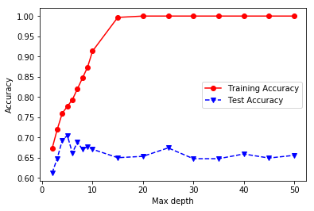

```python
# Plot of training and test accuracies
plt.plot(maxdepths,trainAcc,'ro-',maxdepths,testAcc,'bv--')
plt.legend(['Training Accuracy','Test Accuracy'])
plt.xlabel('Max depth')
plt.ylabel('Accuracy')
```

###### Over-fitting in SVM

Support vector machine produces nonlinear boundaries by constructing a linear boundary in a large, transformed version of the feature space. In essence, the SVM classifier is solving a function-fitting problem using a particular criterion and form of regularization. Hence overfitting in SVM depends on the choice of the regularization parameter C as well as the kernel parameters in the case of non-linear SVMs.  
The C parameter trades off correct classification of training examples against maximization of the decision function’s margin. Larger values of C, encourages smaller margins and more complex decision functions , while a lower value of C will encourage a larger margin and in essence a simpler decision function.  
The behavior of the model is very sensitive to the gamma parameter. If gamma is too large, the radius of the area of influence of the support vectors only includes the support vector itself and no amount of regularization with C will be able to prevent overfitting.

###### Under-fitting in SVM

When gamma is very small, the model is too constrained and cannot capture the complexity or “shape” of the data. The region of influence of any selected support vector would include the whole training set. The resulting model will behave similarly to a linear model with a set of hyperplanes that separate the centers of high density of any pair of two classes.

We would adopt the dataset used in the Decision Tree discussion to illustrate the problem of overfitting/underfitting in the SVM model.

```python
C = [0.01, 0.1, 0.2, 0.5, 0.8, 1, 5, 10, 20, 50]
SVMtrainAcc = []
SVMtestAcc = []

for param in C:
    clf = svm.SVC(C=param,kernel='rbf',gamma='auto')
    clf.fit(X_train, Y_train)
    Y_predTrain = clf.predict(X_train)
    Y_predTest = clf.predict(X_test)
    SVMtrainAcc.append(accuracy_score(Y_train, Y_predTrain))
    SVMtestAcc.append(accuracy_score(Y_test, Y_predTest))
```

```python
# We show the train and test accuracies against the C parameter values
pd.DataFrame(data=np.array([SVMtrainAcc,SVMtestAcc]),index=["train Accuracy", "test Accuracy"], columns=C)
```

|  | 0.01 | 0.1 | 0.2 | 0.5 | 0.8 | 1.0 | 5.0 | 10.0 | 20.0 | 50.0 |
| --- | --- | --- | --- | --- | --- | --- | --- | --- | --- | --- |
| train Accuracy | 0.513333 | 0.606667 | 0.766667 | 0.816667 | 0.823333 | 0.8500 | 0.896667 | 0.896667 | 0.913333 | 0.940000 |
| test Accuracy | 0.496667 | 0.549167 | 0.678333 | 0.714167 | 0.715000 | 0.7125 | 0.647500 | 0.649167 | 0.636667 | 0.621667 |

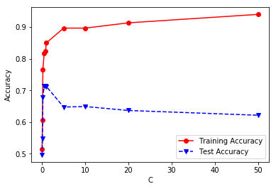

```python
# Plot of training and test accuracies
plt.plot(C,SVMtrainAcc,'ro-',C,SVMtestAcc,'bv--')
plt.legend(['Training Accuracy','Test Accuracy'])
plt.xlabel('C')
plt.ylabel('Accuracy')
```

###### We would now illustrate how sensitive the gamma parameter is to the SVM model with C fixed at 1. When gamma is very small, the model is too constrained and fails to model or capture the structure/pattern of the data. When gamma is too large, overfitting becomes inevitable.

```python
gamma = [0.0001,0.001,0.01, 0.1, 0.2, 0.5, 0.8, 1, 5, 10, 20, 50]
SVMtrainAcc = []
SVMtestAcc = []

for param in gamma:
    clf = svm.SVC(C=1,kernel='rbf',gamma=param)
    clf.fit(X_train, Y_train)
    Y_predTrain = clf.predict(X_train)
    Y_predTest = clf.predict(X_test)
    SVMtrainAcc.append(accuracy_score(Y_train, Y_predTrain))
    SVMtestAcc.append(accuracy_score(Y_test, Y_predTest))
```

```python
# We show the train and test accuracies against the gamma parameter values
pd.DataFrame(data=np.array([SVMtrainAcc,SVMtestAcc]),index=["train Accuracy", "test Accuracy"], columns=gamma)
```

|  | 0.0001 | 0.001 | 0.01 | 0.1 | 0.2 | 0.5 | 0.8 | 1.0 | 5.0 | 10.0 | 20.0 | 50.0 |
| --- | --- | --- | --- | --- | --- | --- | --- | --- | --- | --- | --- | --- |
| train Accuracy | 0.513333 | 0.6200 | 0.763333 | 0.766667 | 0.793333 | 0.8500 | 0.876667 | 0.890000 | 0.966667 | 0.993333 | 0.996667 | 1.000000 |
| test Accuracy | 0.496667 | 0.5925 | 0.725833 | 0.739167 | 0.725000 | 0.7125 | 0.682500 | 0.668333 | 0.623333 | 0.609167 | 0.592500 | 0.555833 |

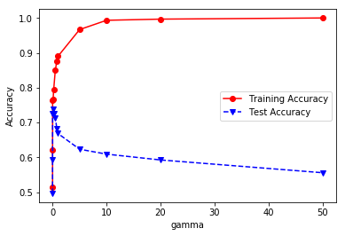

```python
# Plot of training and test accuracies
plt.plot(gamma,SVMtrainAcc,'ro-',gamma,SVMtestAcc,'bv--')
plt.legend(['Training Accuracy','Test Accuracy'])
plt.xlabel('gamma')
plt.ylabel('Accuracy')
```

###### We would now illustrate that when the gamma value is very high, overfitting is inevitable and and no amount of regularization with C will be able to prevent overfitting.

```python
import itertools
C_gamma = [(0.01,180), (0.1,180), (0.2,180), (0.5,180), (0.8,180), (1,180), (5,180), (10,180), (20,180), (50,180)]

SVMtrainAcc = []
SVMtestAcc = []

for param in C_gamma:
    clf = svm.SVC(C=param[0],kernel='rbf',gamma=param[1])
    clf.fit(X_train, Y_train)
    Y_predTrain = clf.predict(X_train)
    Y_predTest = clf.predict(X_test)
    SVMtrainAcc.append(accuracy_score(Y_train, Y_predTrain))
    SVMtestAcc.append(accuracy_score(Y_test, Y_predTest))
```

```python
# We show the train and test accuracies against the gamma parameter values
pd.DataFrame(data=np.array([SVMtrainAcc,SVMtestAcc]),index=["train Accuracy", "test Accuracy"], columns=C_gamma)
```

|  | (0.01, 180) | (0.1, 180) | (0.2, 180) | (0.5, 180) | (0.8, 180) | (1, 180) | (5, 180) | (10, 180) | (20, 180) | (50, 180) |
| --- | --- | --- | --- | --- | --- | --- | --- | --- | --- | --- |
| train Accuracy | 0.513333 | 0.513333 | 0.513333 | 0.536667 | 1.0000 | 1.000000 | 1.000000 | 1.000000 | 1.000000 | 1.000000 |
| test Accuracy | 0.496667 | 0.496667 | 0.496667 | 0.496667 | 0.5075 | 0.516667 | 0.521667 | 0.521667 | 0.521667 | 0.521667 |

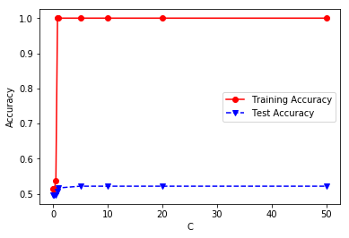

```python
# Plot of training and test accuracies
plt.plot(C,SVMtrainAcc,'ro-',C,SVMtestAcc,'bv--')
plt.legend(['Training Accuracy','Test Accuracy'])
plt.xlabel('C')
plt.ylabel('Accuracy')
```